# Practical Machine Learning Project - Quantified Self Movement Data Analysis Report

by Luis Alejandro Pinto Valdiviezo

## Introduction

Using devices such as Jawbone Up, Nike FuelBand, and Fitbit it is now possible to collect a large amount of data about personal activity relatively inexpensively. These type of devices are part of the quantified self movement - a group of enthusiasts who take measurements about themselves regularly to improve their health, to find patterns in their behavior, or because they are tech geeks. One thing that people regularly do is quantify how much of a particular activity they do, but they rarely quantify how well they do it.

In this project, we will use data from accelerometers on the belt, forearm, arm, and dumbell of 6 participants to predict the manner in which they did the exercise.

## Load libraries and Data

```r
library(caret)
library(rpart)
library(randomForest)
library(rattle)
```

```r
library(rpart.plot)
library(corrplot)
```

```r
trainingDataURL <- "https://d396qusza40orc.cloudfront.net/predmachlearn/pml-training.csv"
trainingData <- read.csv(trainingDataURL)
testingDataURL <- "https://d396qusza40orc.cloudfront.net/predmachlearn/pml-testing.csv"
testingData <- read.csv(testingDataURL)
```

```r
dim(trainingData)
```

```
## [1] 19622   160
```

```r
dim(testingData)
```

```
## [1]  20 160
```

The training data set contains 19622 observations and 160 variables, while the testing data set contains 20 observations and 160 variables.

## Cleaning Data

At this step, we will clean the data removing the columns that contains missing values. Also, we will remove meaningless variables.

```r
trainingDataMS <- trainingData[,colSums(is.na(trainingData))==0]
testingDataMS <- testingData[,colSums(is.na(trainingData))==0]
dim(trainingDataMS)
```

```
## [1] 19622    93
```

```r
dim(testingDataMS)
```

```
## [1] 20 93
```

The training and testing data set contains 93 variables. We consider all variables which refer to 3-dimensional records meaningless or factor because their information is captured in the summary variables like: max, min, mean, etc.

```r
trainRemove <- grepl("problem_id|^X|_x$|_y$|_z$", colnames(trainingDataMS))
testRemove <- grepl("problem_id|^X|_x$|_y$|_z$", colnames(testingDataMS))
cleanTrainData <- trainingDataMS[ , !trainRemove]
cleanTestData <- testingDataMS[ , !testRemove]
classe <- cleanTrainData$classe
testCleaned <- cleanTestData[, sapply(cleanTestData, is.numeric)]
trainCleaned <- cleanTrainData[, sapply(cleanTrainData, is.numeric)]
trainCleaned$classe <- classe
dim(trainCleaned)
```

```
## [1] 19622    20
```

After completing the cleaning process, the training and testing data set contains 20 variables.

## Split the data

```r
set.seed(22519)
inTrain <- createDataPartition(trainCleaned$classe, p=0.70, list=F)
trainData <- trainCleaned[inTrain, ]
testData <- trainCleaned[-inTrain, ]
```

## Data Modeling

We fit a predictive model for activity recognition using Random Forest algorithm because it automatically selects important variables and is robust to correlated covariates & outliers in general. We will use 5-fold cross validation

```r
controlRf <- trainControl(method="cv", 5)
modelRf <- train(classe ~ ., data=trainData, method="rf",trControl=controlRf, ntree=250)
```

Then, we estimate the performance of the model on the validation data set.

```r
predictRf <- predict(modelRf, testData)
confusionMatrix(testData$classe, predictRf)
```

```
## Confusion Matrix and Statistics
##
##           Reference
## Prediction    A    B    C    D    E
##          A 1674    0    0    0    0
##          B    1 1137    1    0    0
##          C    0    0 1025    1    0
##          D    0    0    0  964    0
##          E    0    0    0    0 1082
##
## Overall Statistics
##
##                Accuracy : 0.9995
##                  95% CI : (0.9985, 0.9999)
##     No Information Rate : 0.2846
##     P-Value [Acc > NIR] : < 2.2e-16
##
##                   Kappa : 0.9994
##  Mcnemar's Test P-Value : NA
##
## Statistics by Class:
##
##                      Class: A Class: B Class: C Class: D Class: E
## Sensitivity            0.9994   1.0000   0.9990   0.9990   1.0000
## Specificity            1.0000   0.9996   0.9998   1.0000   1.0000
## Pos Pred Value         1.0000   0.9982   0.9990   1.0000   1.0000
## Neg Pred Value         0.9998   1.0000   0.9998   0.9998   1.0000
## Prevalence             0.2846   0.1932   0.1743   0.1640   0.1839
## Detection Rate         0.2845   0.1932   0.1742   0.1638   0.1839
## Detection Prevalence   0.2845   0.1935   0.1743   0.1638   0.1839
## Balanced Accuracy      0.9997   0.9998   0.9994   0.9995   1.0000
```

So, the estimated accuracy of the model is 99.95%.and the estimated out-of-sample error is 0.05%

## Predicting for Test Data Set

Now, we apply the model to the original testing data set downloaded from the data source.

```r
result <- predict(modelRf, testCleaned)
result
```

```
##  [1] B A B A A E D B A A B C B A E E A B B B
## Levels: A B C D E
```

## Appendix: Figures

1. Correlation Matrix Visualization

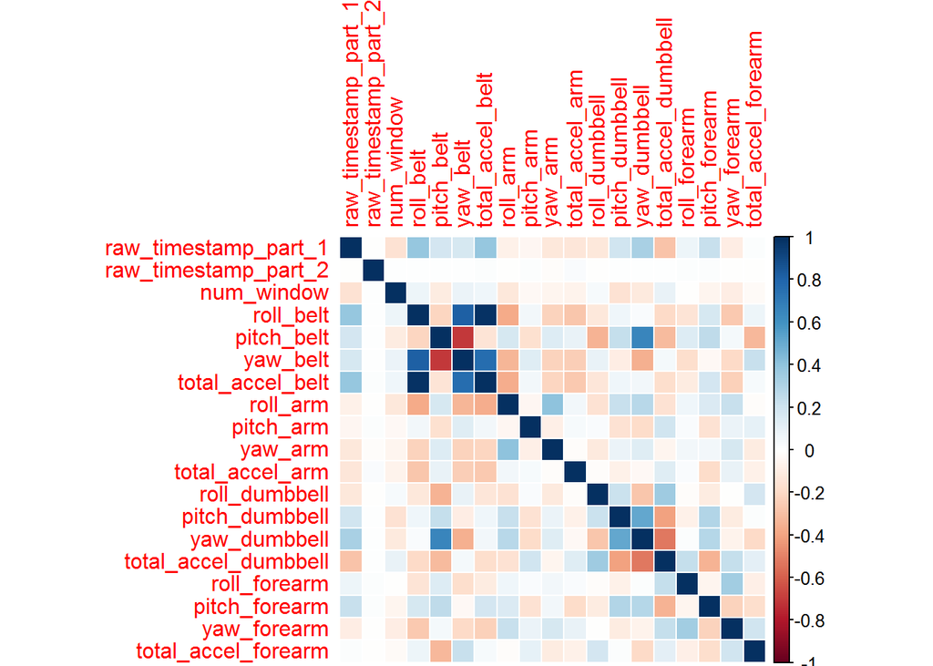

```r
corrPlot <- cor(trainData[, -length(names(trainData))])
corrplot(corrPlot, method="color")
```